DS 6030 | Fall 2023 | University of Virginia

# Statistical Learning Final Project

Author

**Kevin Finn, Will Sivolella, Jack Gallagher**

Published

December 11, 2023

# Causal Analysis

Causal analysis within the realm of machine learning represents a dynamic and interdisciplinary pursuit, integrating advanced statistical methodologies, expert domain knowledge, and a nuanced understanding of causation. In this emerging field, there lies a distinct opportunity to elevate the efficacy of machine learning models, imbuing predictions with enhanced robustness and interpretability. This is particularly pertinent in intricate systems where the discernment of causal relationships is imperative for informed decision-making.

## Causation vs. Correlation: A Fundamental Distinction

At the heart of causal inference lies a pivotal distinction between causation and correlation. Causation denotes a direct and substantive link between a presumed cause and its ensuing effect. When a change in one variable consistently leads to a change in another, causation is inferred. However, the intricate nature of real-world data introduces the possibility of confounding factors, complicating the straightforward determination of causation.

## Example: Ice Cream Sales and Unlikely Correlations

Illustrating this point is the classic example examining the purported causal effect between ice cream sales and crime or drowning incidents. Superficially, a substantial correlation between these variables is apparent. Closer inspection reveals this association to be spurious. Behind the scenes, the connection emerges as a consequence of shared influences, primarily dictated by the weather. Ice cream sales surge during warmer months, aligning with increased outdoor activities, including swimming and beach attendance. Simultaneously, higher temperatures correlate with an uptick in drowning incidents and certain types of crime. This example underscores the importance of differentiating between correlation and causation, emphasizing that predictive measures alone do not provide a reliable gauge of causality.

## Moving Beyond Correlations: The Essence of Causal Analysis

The essence of causal analysis lies in transcending superficial observations of correlations and delving into the intricate web of underlying mechanisms propelling specific outcomes. By doing so, practitioners can unravel the complexities of cause-and-effect relationships, discerning the true drivers of phenomena. As machine learning models become increasingly sophisticated, incorporating causal analysis not only enhances the accuracy of predictions but also empowers decision-makers to comprehend and intervene effectively in complex systems. This strategic fusion of statistical acumen and domain expertise paves the way for a deeper understanding of causation within the evolving landscape of machine learning.

# Causal Forest

## Causal Forest Description

The concept of Causal Forest is rooted in the framework of Random Forests, which comprises multiple independent decision trees operating at various levels. Each decision tree is trained on a specific predictor or subset of the data, and their predictions collectively contribute to creating a more robust predictive model. Distinguishing itself from the Random Forest approach, Causal Forest integrates concepts from causal inference. While Random Forest primarily focuses on minimizing prediction error, Causal Forest aims to optimize data splits by maximizing differences across each split based on the relationships between response and predictor variables. A key distinction lies in the handling of confounding variables, where the Causal Forest algorithm strives to balance covariates across data splits, ensuring fair comparisons in each decision tree to capture true causal relationships. The overarching objective of Causal Forests is to examine how the effects of predictors vary across a sample.

## Causal Forest R package

For the implementation of Causal Forest in R, the grf package proves instrumental, featuring the causal_forest function. This function facilitates the creation of our model, and the package offers additional tools for analyzing the causal effects of predictor variables and assessing the accuracy of our predictive model.

# Specific Implementation: Causal Forest and MLB Hall of Fame Data

## EDA

The dataset under consideration derives from the Lahman Baseball Dataset, encompassing individuals who have received Hall of Fame votes as determined by the Baseball Writers Association of America (BBWAA), with a focus on post-1950 records. The integration of this dataset involved merging it with several supplementary tables from the Lahman database, incorporating pertinent information such as player positions and statistical performance metrics. Subsequently, the dataset was stratified into distinct categories, namely pitchers and hitters, and meticulously prepared for application in a random forest analysis.

## Modeling

In our modeling approach, we are constructing multiple Causal Forests, with each predictor variable designated as the treatment, while simultaneously controlling for the remaining predictors. The primary objective is to discern the individual effects of each predictor while maintaining the other predictors at constant levels. This enables us to identify the most influential player statistics that significantly contribute to the likelihood of a player being elected into the Hall of Fame.

As part of our analysis, we have implemented this methodology for various batting and pitching statistics. For instance, the following code snippet demonstrates the setup for the ‘Runs’ statistic. This process has been iteratively applied to each relevant batting and pitching metric.

```r
split <- sample(c(FALSE, TRUE), nrow(HOF_hit), replace = TRUE)
HOF_hit.train <- HOF_hit[split,]
HOF_hit.hold <- HOF_hit[!split,]


# Isolate the "treatment" as a matrix
treatRuns <- as.matrix(HOF_hit.train$R)

# Isolate the outcome as a matrix
HOFhitoutcome <- as.matrix(HOF_hit.train$HOF)

# Use model.matrix to get our predictor matrix
# We might also consider adding interaction terms
Xruns <- model.matrix(lm(HOF ~ -1 + H + X2B + X3B + HR +
                       RBI + SB + BB + BA + OBP +
                       SLG, data = HOF_hit.train))

# Estimate causal forest
cfRuns <- causal_forest(Xruns,HOFhitoutcome,treatRuns, num.trees = 5000)

# Get predicted causal effects for each observation
effectsRuns <- predict(cfRuns)$predictions

# And use holdout X's for prediction
X.holdRuns <- model.matrix(lm(HOF ~ -1 + H + X2B + X3B + HR +
                       RBI + SB + BB + BA + OBP +
                       SLG, data = HOF_hit.hold))
# And get effects
effects.holdRuns <- predict(cfRuns, X.holdRuns)$predictions

# Get standard errors for the holding data predictions - we probably should have set the num.trees
# option in causal_forest higher before doing this, perhaps to 5000.
SEsRuns <- sqrt(predict(cfRuns, X.holdRuns, estimate.variance = TRUE)$variance.estimates)
```

```r
estimated_effectsRuns <- effectsRuns

# Extract standard errors
standard_errorsRuns <- SEsRuns

# Calculate z-scores
z_scoresRuns <- estimated_effectsRuns / standard_errorsRuns

# Set a significance level (e.g., 0.05)
significance_level <- 0.05

# Check significance
significant_effectsRuns <- abs(z_scoresRuns) > qnorm(1 - significance_level / 2)

HittingData<-rbind(HittingData, c("R", sum(significant_effectsRuns), sum(!significant_effectsRuns), sum(significant_effectsRuns)/(sum(significant_effectsRuns)+sum(!significant_effectsRuns)), mean(effectsRuns)))
```

## Results

To illustrate the outcomes of our Causal Forest model, we have generated both box plots and bar plots. For each category—batting and pitching—two distinct plots have been crafted to provide a comprehensive overview.

### Boxplots

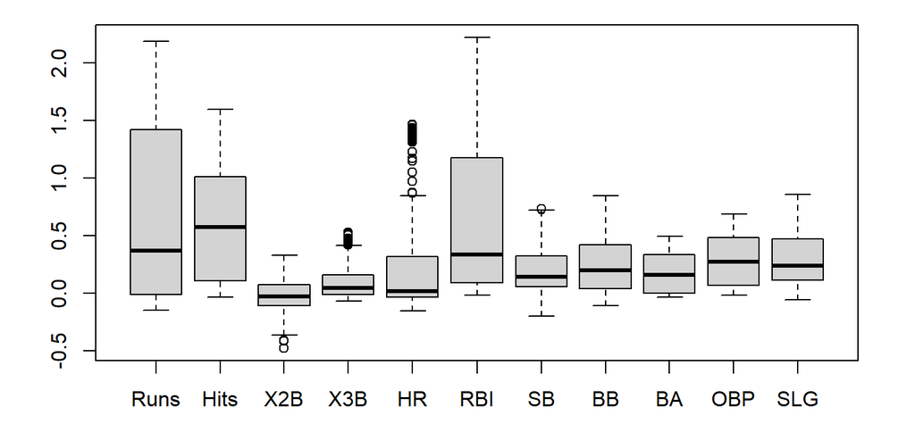

Hitters

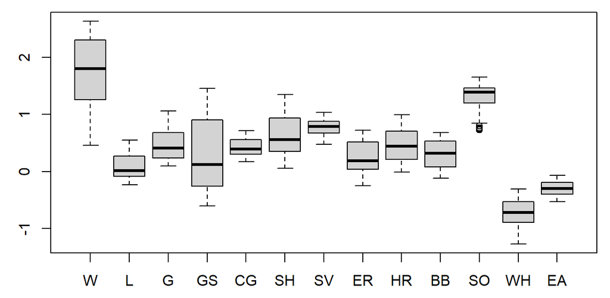

Pitchers

### Barplots

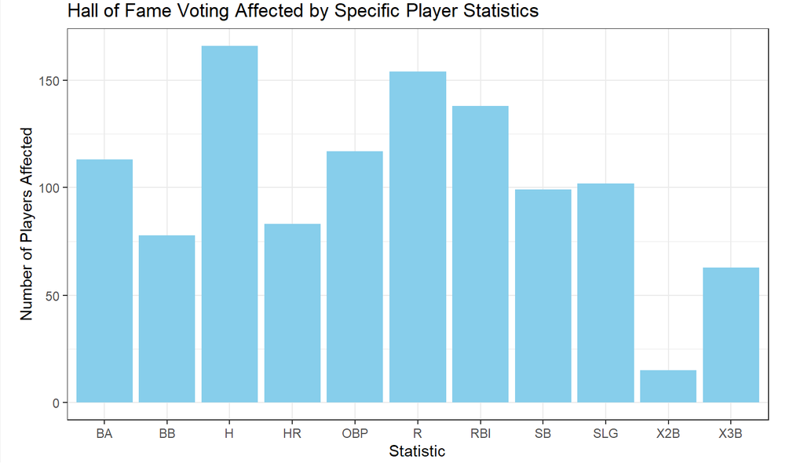

Hitters

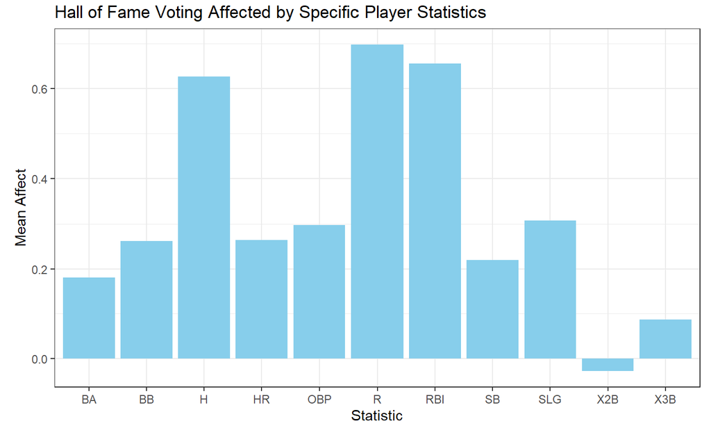

Hitters

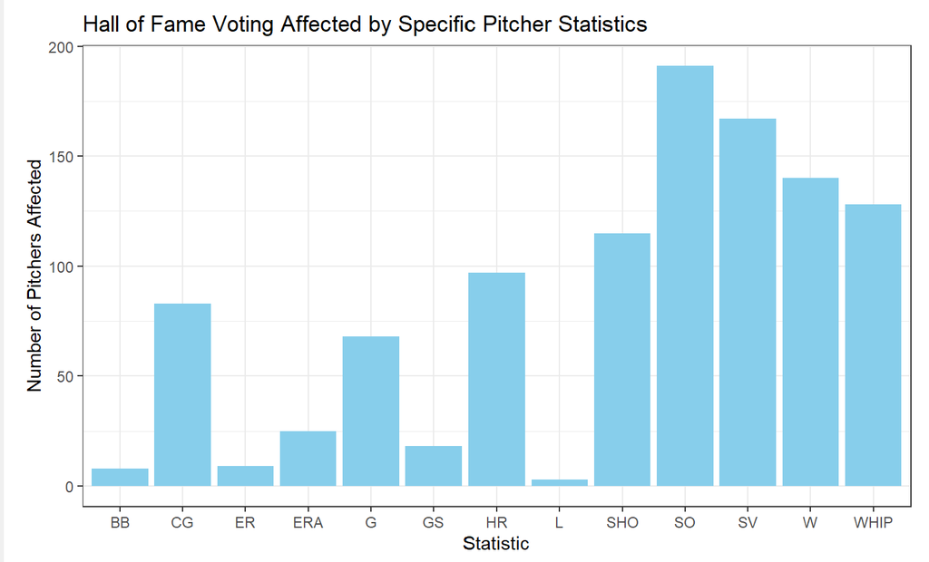

Pitchers

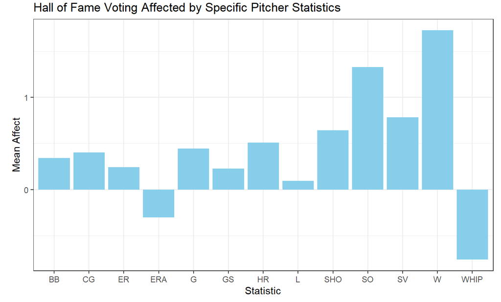

Pitchers

#### Barplot Descriptions

The bar plots show the number of players affected by each statistic when determining the likelihood of them making the Hall of Fame and the mean effect of each statistic when determining the likelihood of players’ making the Hall of Fame.

# Conclusion

This study serves as a tangible demonstration of the practical application of causal analysis, offering valuable insights into the factors that significantly influence a player’s likelihood of making it into the Hall of Fame. Through rigorous causal analysis techniques, we were able to discern the impacts of each variable, encompassing various career statistics, on the intricate process of determining Hall of Fame induction. This real-world example showcases the power of causal analysis in unraveling the complex interplay between individual player performance metrics and the ultimate recognition bestowed upon them. Such insights not only contribute to a deeper understanding of the dynamics underlying Hall of Fame selections but also provide a robust framework for informed decision-making and strategic considerations within the realm of baseball analytics.

In a broader context, this investigation underscores the versatility of causal analysis methodologies beyond the specific domain of baseball. The ability to disentangle causal relationships between variables extends to numerous fields, from social sciences and economics to healthcare and policy-making. By employing rigorous causal analysis, researchers and decision-makers gain a systematic approach to uncovering the drivers of outcomes, allowing for more informed and strategic interventions. The success of this study in unraveling the complexities of Hall of Fame induction criteria exemplifies how causal analysis can illuminate the underlying mechanisms in any complex system. As we delve into the intricacies of causal relationships, we pave the way for a more nuanced understanding of phenomena and, consequently, more effective decision-making in a wide array of disciplines.

For complete code and all the models, please refer to the qmd file on authors’ Github: https://github.com/kjfinn1/DS6030-Final-Project

# References

## Reference List

[1]“Causal Forest,” LOST. https://lost-stats.github.io/Machine_Learning/causal_forest.html (accessed Dec. 11, 2023).

[2]M. Barrett, “Causal Inference in R.” https://www.r-causal.org/ (accessed Dec. 11, 2023).

[3]M. White, “Explicitly Optimizing on Causal Effects via the Causal Random Forest: A Practical Introduction and Tutorial — Mark H. White II, PhD,” Mark H.R White II, PhD, Oct. 14, 2018. Accessed: Dec. 11, 2023. [Online]. Available: https://www.markhw.com/blog/causalforestintro

## Software Used

Tidyverse

Lahman

ggplot2

Grf

dplyr